# Teste de Hipótese

Alexandre Nicolella

nicolella@usp.br

FEARP/USP

2026-04-27

# Teste de Hipótese

## Procedimento Geral

## Introdução

- Estimamos características da população: estimativa pontual e a estimativa de intervalo de um parâmetro.
- Gostariamos de testar se uma teoria é mais plausível do que outra com base na realidade.
- Testar se uma **hipótese** sobre a população é mais plausível
- Se os dados amostrais trazem evidências que apoiam ou não essa hipótese.

## Introdução: Exemplo

**EXEMPLO**

- Verificar se um determinado medicamento não tem efeito sobre a mortalidade causada por um determinado virus ou se possui efeito.
- Verificar se a quantidade de gordura anunciado pelo fabricante de um produto realmente está correta ou é maior.
- Se a afirmativa de um canditado de que possui a maioria dos votos é verdadeira ou é menor.
- Verificar se as rendas entre duas comunidades são as mesmas para podermos lançar uma política de apoio
- Verifcar se uma política do aumento do recurso as empresas não afeta falência ou se tem efeito.

## Introdução: Lógica

- Faremos algo muito parecido com os tribunais, assumimos que a pessoa ou empresa é “inocente”.
  - Que o medicamento não tem efeito,
  - Que o teor de gordura está certo,
  - Que o candidato tem maioria,
  - Que as comunidades possuem a mesma renda,
  - Que o recurso não afeta o número de falências.
  - Partimos da premissa de que a hipótese inicial é a correta e tentamos verificar com os fatos (dados amostrais) se essa hipótese colocada é verossímil.

## Construíndo a Hipótese Nula

**EXEMPLO**

Uma ONG que combate fome e pobreza afirma que uma determinada comunidade deveria receber um programa do governo pois possui renda per capita de R$600,00, a qual a torna elegível ao programa. Entretanto, os gestores do programa acham que esse valor está subestimado e que na verdade a renda seria maior. A questão é como saber quem está correto, a ONG ou o Governo?

## Construíndo a Hipótese Nula

- Dessa forma temos duas hipóteses distintas:
  - A que diz que a esperança da renda pc é de R$600
  - A outra proposição que diz que a renda dessa população é maior que R$600.
- Vamos assumir que a ONG tem razão e chamaremos essa afirmativa de **hipótese nula** ou $H_0$, $\mu$ é de R$600. Podemos de forma condensada dizer:

$$H_0: \qquad \mu=600$$

- Já o governo que está contextando chamaremos sua hipótese de alternativa, $H_1$. Dessa forma:

$$H_1: \qquad \mu>600$$

## Construíndo a Hipótese Nula

- Quem tem razão nessa história?
  - Devemos aceitar ou rejeitar a hipótese nula $H_0$ - de que a esperança da renda pc é de 600 - em detrimento a hipótese alternativa $H_1$ que afirma que a renda é maior do que 600. Juntas:

$$H_0: \qquad \mu=600$$
$$H_1: \qquad \mu>600$$

## O Teste Estatístico

- Temos as as duas teorias concorrentes,
- Como testar qual é mais plausível?
- Faremos um processo de amostragem, onde faremos $n$ medições da renda pc (que chamaremos de X), $X_1, X_2, ..., X_n$, e obteremos os valores de renda pc $x_1, x_2,...x_n$.
- Com dados amostrais faremos algum tipo de cálculo que nos permite inferir se $H_0$ é plausível ou não
- Teste Estaístico:

## O Teste Estatístico

**DEFINIÇÃO**

**Teste Estatístico**:

Suponha um processo de amostragem com $n$ medições de $X$, $X_1, X_2, ...,X_n$, com valores observados $x_1, x_2, ...,x_n$. Um teste estatístico é uma estatística:
$$T = h(X_1,X_2, . . .,X_n)$$
a qual será utilizada para decidir se aceitamos ou rejeitamos $H_0$

## O Teste Estatístico: a distribuição

- Qual a distribuição dessa estatística sob a condição de que a hipótese $H_0$ for a verdadeira?
- Queremos saber se a amostra tivesse sido extraída de uma população com esperança da renda pc, $\mathbb{E}(X)$, de R$ 600, quais seriam os valores típicos para a distribuição do estimador T?
- Depois comparamos com o que obtivemos no processo de amostragem.

**EXEMPLO**

Gostariamos de verificar a hipótese de que a esperança da renda pc, $\mu$ é de R$600. Uma alternativa de teste estatístico é a média, $\bar{X}$. O teste estatístico seria:

$\bar{X} = \frac{\sum_i^n(X_i)}{n}$

Com base na amostra observada $x_1, x_2, ..., x_3$ poderiamos obter a estimativa da renda pc. Como decidir se essa média calculada nos traz mais evidência a favor de $H_0$ ou $H_1$?

## O Teste Estatístico: a distribuição

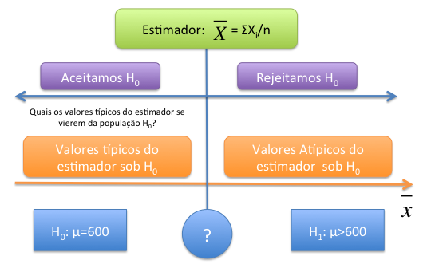

Teste de Hipótese - intuição

## O Teste Estatístico: a decisão

- A figura considera o estimador $\bar{X}$.
- A esquerda temos os valores do estimador que atestam que a hipótese $H_0$ é a mais plausível,
  - Quando mais próxima a estimativa de R$600 maior evidência que $H_0$ é verdadeira.
- Ao caminhar para a direita, os valores do estimador se distanciam de 600, e mais evidência de que $H_0$ não é plausível.
- Precisamos de um ponto de corte (interrogação na figura) onde valores menores do estimador são favoráveis a hipótese nula e valores maiores são mais favoráveis a hipótese alternativa.
- Se no nosso processo de amostragem obtivemos a estimativa de $\bar{x}=700$, isso é mais favorável a $H_0$ ou $H_1$?

## O Teste Estatístico: a distribuição

- Para saber se esse valor é mais favorável a qual hipótese, precisamos descobrir quais seriam os valores típicos do estimador $\bar{X}$ se viesse de $H_0$.
- Isso está presente a esquerda da figura, quais os valores típicos para $\bar{X}$ que veio de uma população com $\mu=600$?
- Considere que a população $X$ seja $N(600,100^2)$, ou seja, tem esperança 600 e desvio padrão populacional de 100.
  - Essa é a afirmação da ONG, ou seja, nosso $H_0$.
- Sabemos que o estimador $\bar{X}$ terá uma distribuição $N(600,\frac{100^2}{n})$.
  - Supondo uma amostra de 25 pessoas, sob $H_0$, tem-se $N(600,\frac{100^2}{25})$.
- Veja a simulação abaixo

## O Teste Estatístico: a distribuição

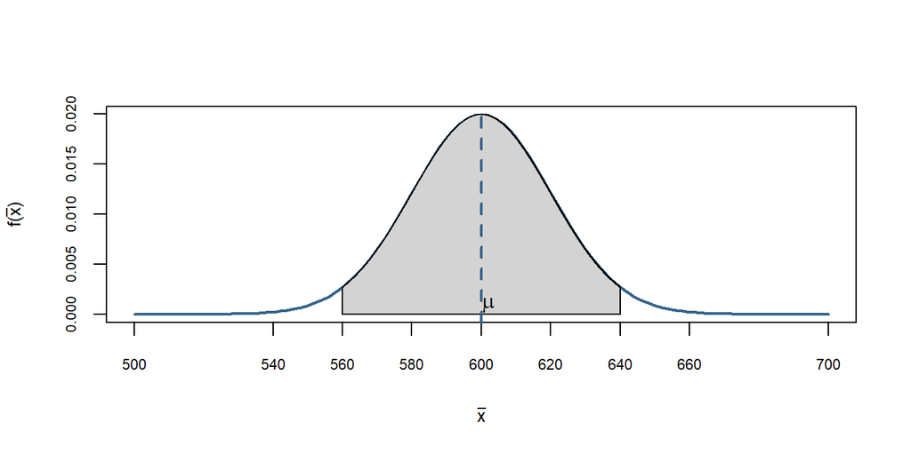

Valores típicos da distribuiçao da média sob H0

## O Teste Estatístico: a distribuição

- No centro temos a $E(\bar{X})=\mu=600$.
- Dado a amostra e sob $H_0$ os valores típicos oscilam mais ou menos entre 560 e 640 - dois desvios padrão para cima e para baixo
  - lembrem-se que nesse intervalo temos mais de 95% das observaçoes.
- Na nossa amostragem obtivemos $\bar{x}=700$.
  - Observe no gráfico o valor de 700 - muita a frente
  - A probabilidade de obtermos esse valor de média com uma amostra retirada da população $N(600,100^2)$, é praticamente 0.
- Existem evidências de que essa amostra não veio de uma população conforme descrita pela ONG e sim de uma população com esperança maior do que R$600.
- Portanto, dizemos que rejeitamos $H_0$

## Probabilidade da cauda e o p-valor

- Uma outra maneira que podemos olhar
- Considere a figura acima da distribuição da média retirada de uma população sob $H_0$, ou seja, $N(600,100^2)$.
- Qual seria a probabilidade de acharmos valores iguais ou maiores do que 700 nessa distribuição?
- Essa é chamada probabilidade de cauda a direita $P(\bar{X}\geq 700|H_0)$ e mais conhecida como **p-valor.**
- Podemos computar esse valor para a cauda inferior, para a superior ou para ambas, a depender da hipótese feita.
- Quando mais a direita estiver o nosso valor calculado, menor será essa probabilidade e maior serão as evidências contra $H_0$.

## Probabilidade da cauda e o p-valor

**EXEMPLO**

No nosso exemplo:

$$P(\bar{X}\geq 700|H_0 \Rightarrow \bar{X} \sim N(600,\frac{100^2}{25}))$$

$$P(Z_{\bar{X}}\geq \frac{700-600}{100/5}|H_0)$$

$$P(Z_{\bar{X}} \geq \frac{100}{20})=P(Z_{\bar{X}} \geq 5)=0$$

- Notamos que esse valor de $z_c$ é muito alto, probabilidade é de zero.
- O p-valor nesse caso é igual a 0
  - Mostrando uma forte evidência de que a ONG está enganada

## Como decidir para casos mais próximos?

- Exemplo extremo para compreender a intuição do processo.
- Precisamos decidir a partir de que ponto exatamente dizemos que pertence a população sob $H_0$.
- E a partir de que ponto não pertence.
- Para isso precisamos entender os erros que podemos cometer ao fazer esse julgamento.

## Erro Tipo I (EI) e Erro Tipo II (EII): o conceito

- Duas ideias,
  - A primeiro é a existência da verdadeira população
  - A segunda é o que achamos ser a verdadeira população com base na análise que fizemos.
- Surge o que chamamos de erro estatístico.
  - Não temos como fugir dele, somente controlá-lo. Vejamos a tabela abaixo que resume as possibilidades:

Table 1: Tipos de Erros em Estatística, EI e EII.

| A Decisão | $H_0$ é verdadeiro | $H_1$ é verdadeiro |
| --- | --- | --- |
| **Rejeitar $H_0$** | Erro Tipo I (EI) | Correto |
| **Não Rejeitar $H_0$** | Correto | Erro Tipo II (EII) |

## Erro Tipo I (EI) e Erro Tipo II (EII): o conceito

**DEFINIÇÃO**

**Erro Tipo I e Erro Tipo II**

Erro Tipo I (EI) ocorre quando “indevidamente” rejeitamemos $H_0$. Nesse caso $H_0$ era verdadeira e rejeitamos.

Erro Tipo II (EII) ocorre quando “indevidamente” não rejeitamos $H_0$. Nesse caso não rejeitamos $H_0$ e na verdade $H_1$ é verdadeira.

## EI e EII: encontrando um critério de decisão

- Nosso desafio agora é estabelecer um critério de decisão,
  - ponto a partir do qual dizemos que $H_0$ não parece mais provável
- Essa chamaremos de valor crítico.
- Acima ou abaixo desse valor chamaremos de região crítica ou de rejeição,
  - que são os valores a partir dos quais entendemos que $H_0$ não é mais plausível.

**EXEMPLO**

- EI $(\alpha)$- Dizer que a renda é maior que 600, quando na realizadade ela é de 600.
- EII $(\beta)$- Dizer que a renda é de 600 quando na realidade ela é maior do que 600.

## EI e EII: encontrando um critério de decisão

- Conseguimos calcular o Erro Tipo I $(\alpha)$ com base na distribuição sob $H_0$, entretanto,
- Como não sabemos qual é a distribuição sob $H_1$, fica difícil calcular o EII $(\beta)$.

## EI e EII: encontrando um critério de decisão

- Retomando nosso exemplo: ONG afirma que uma comunidade tem renda de R$600.
- Sob $H_0$, e uma amostra de 25, $N \bigg(600,\frac{100^2}{25} \bigg)$
- Hipóteses eram:

$$H_0: \qquad \mu=600$$

$$H_1: \qquad \mu>600$$

- Controlar o Erro Tipo I $(\alpha)$ para encontrar a região crítica.
- Gostariamos de cometer o Erro Tipo I em apenas 5% dos casos.
  - A chance de retirarmos um amostra da pop sob $H_0$ e o valor da estimativa ser maior que o valor de decisão é de 5% dos casos, os outros 95% sempre cairão na área de aceitação.

## EI e EII: encontrando um critério de decisão

- Vejamos como podemos encontrar o critério de decisão para o nosso caso, unicaudal.

**EXEMPLO**

$$P(Z_{\bar{X}} \geq z_c|H_0)=0.05= \alpha$$

Olhando a tabela temos:

$$P(Z_{\bar{X}} \geq 1.65|H_0)=0.05= \alpha$$

$$z_c =\frac{\bar{X}+600}{100/5} \Rightarrow 1.65 = \frac{\bar{X}+600}{20} \Rightarrow \bar{X}=600+1.65*20=633$$

Portanto,

$$P(\bar{X}\geq 633|H_0)=0.05= \alpha$$

## EI e EII: encontrando um critério de decisão

- Nossa regra controla o Erro Tipo I.
- Para nosso exemplo: Rejeitar $H_0$ toda vez que o valor calculado da estimativa de $\bar{X}$ for maior do que 633 e aceitar quando for menor.
- Assim nossa região crítica será:

$$RC =\{\bar{x} \in \mathbb{R} | \bar{x} \geq 633\}$$

- Essa regra implica que a probabilidade de rejeitarmos $H_0$ (de que a renda média não é de 600), e na verdade ela ser de 600 é de 5%.
- Vejamos o gráfico e a região em cinza indicando a RC:

## EI e EII: encontrando um critério de decisão

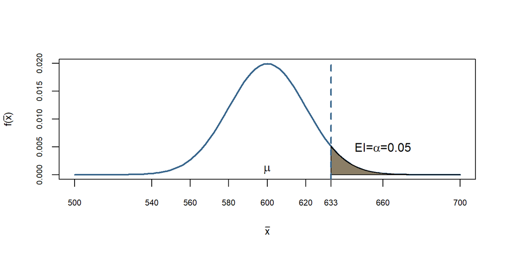

Erro Tipo I e a Região Crítica

## O Erro Tipo II

- Como não sabemos a distribuição sob $H_1$ não conseguimos calcular a probabilidade de não rejeitar $H_0$ e na verdade ela pertencer a distribuição de $H_1$.
- Vamos supor que o governo diga que a renda é de R$ 660 com a mesma variância que a ONG afirmou.
- Nesse caso temos as duas teorias concorrentes explicitadas. Agora sabemos $H_1$ e $H_0$. Dada a nossa regra de decisão, temos:

## O Erro Tipo II

- Regra de Decisão e Erros:

$$P(EI)=P (\overline{X} \in RC | H_0 \quad \text {é verdadeira}\Rightarrow \overline{X} \sim N (600;100^{2}/25))=\alpha=0.05$$

- Podemos calcular também o Erro Tipo II:
  $$\begin{array}{ccc}
  P(E II)=P(\overline{X} \notin R C |H_1 \quad \text { verdadeiro })=\beta
  \\
  \\
  =P(\overline{X} < 633 )| \overline{X} \sim N (660;100^{2}/25)).
  \\
  \\
  =P (z < \frac{633-660}{20})
  \\
  \\
  =P(z<-1,35)=8.85\%=\beta
  \end{array}$$

## O Erro Tipo II

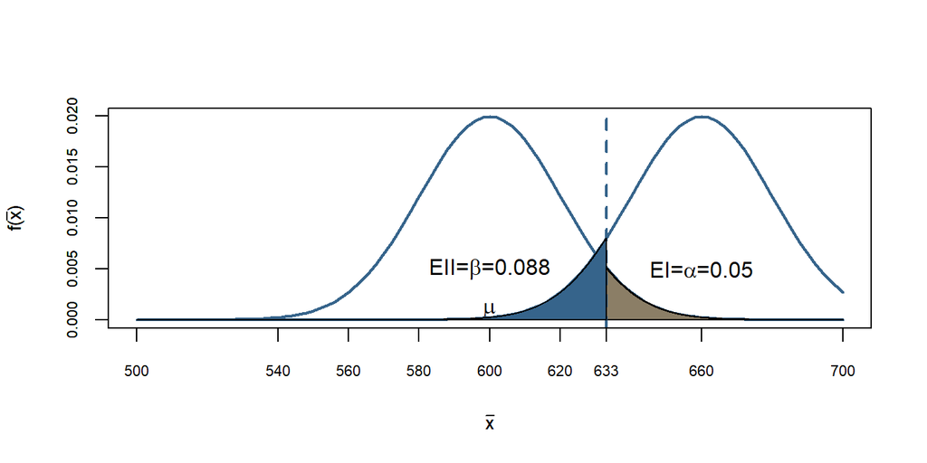

Erro Tipo I e a Região Crítica

## O Erro Tipo I e o Erro Tipo II

- Note que se mudarmos o ponto de corte de 633 para 640, por exemplo, o valor do EI diminui e o valor do EII aumenta.
- Se mudarmos o ponto de corte de 633 para 620 aumentamos o EI e diminuimos o erro EII.
- Importante notar que em geral não conhecemos qual a distribuição está sob $H_1$,
  - a afirmativa concorrente dizia que era maior
  - Prática mais comum e
  - Controlamos então o EI o qual conseguimos calcular e a partir desse controle encontramos os valores da nossa região crítica e montamos nosso teste de hipótese.

## Procedimento Geral do Teste de Hipótese

## Teste para um parâmetro populacional

- Interesse em uma caracteristica da população.
- Teste sob parâmetro populacional
- Unicaudal ou bicaudal:

**Hipótese Unicaudal**:  
Occore quanto temos algum conhecimento do processo. Como no caso anterior, observamos que a ONG tinha dito que a renda era 600 e o governo contextava e dizia que era maior. Logo temos a seguinte formulação geral para o teste unilateral:

$$H_0: \quad \theta=\theta_0$$
$$H_1: \quad \theta>\theta_0 \quad ou \quad \theta<\theta_0$$

## Teste para um parâmetro populacional

**Hipótese Bicaudal**:
Já para o teste bilateral ou bicaudal podemos observar valores maiores ou menores em relação a hipótese nula. Temos a seguinte formulação geral:
$$H_0: \quad \theta=\theta_0$$
$$H_1: \quad \theta \neq \theta_0$$

## Nível de significância

- Tentamos controlar o Erro Tipo I (EI) e achar o valor crítico
- Temos que definir qual seria o tamanho desse erro, 10%, 5%, 1% etc.
- Esse percentual é o que chamamos de nível de significância.
  - Quem define esse tamanho é o pesquisador, em economia, utilizamos os níveis acima.

**DEFINIÇÃO**

**Nível de Significância**:

É a probabilidade máxima aceitável de cometer o erro tipo I e chamamos de $\alpha$, sendo um valor entre $0<\alpha<1$

- Dessa forma, faremos o teste de hipótese para o parâmetro $\theta$ ao nível de significância de $\alpha$.
- No nosso caso dizemos que iremos testar se a renda pc é de 600, $H_0: \mu=600$, ao nível de 5% de significância.

## Estabelencendo Valor Crítico e Região Crítica.

- Com base no nível de significância conseguiremos estabelecer qual é o valor crítico e a região de rejeição.
- Para o nosso caso encontramos o valor crítico de 633 e a nossa região foi estabelecida como $RC =\{\bar{x} \in R | \bar{x} \geq 633\}$.
- Engloba os valores que julgamos não serem mais pertencentes a distribuição sob $H_0$.

**DEFINIÇÃO**

**Valor e região crítica**:

Ao relizar o teste de hipótese de $H_0$ contra $H_1$ utilizando o teste estatístico $T$ ao nível de significância de $\alpha$, o conjunto $C \subset \mathbb{R}$ o qual corresponde a todos os valores de $T$ para os quais rejeitamos a hipótese nula $H_0$, é chamado de **Região Crítica**. O valor na fronteira é o chamado valor crítico

## Estabelencendo Valor Crítico e Região Crítica.

- Assim, de forma geral tem-se:

$$RC =\{T \in C| H_0\}$$
$$P(T \in C|H_0)\leq\alpha$$

- A região crítica depende do teste estatístico escolhido e se a hipótese é unilateral ou bilateral
  - No caso unilateral utilizamos o nível de siginifcância, $\alpha$, todo de um lado.
  - No teste bilateral dividimos o nível de significância, ou seja, utilizamos$\alpha /2$, metade para cada lado.
- Quando mais alto $\alpha$ maior a probabilidade de se obter uma amostra com estimativas pertencentes a região crítica.
  - $\alpha$ maiores implicam em maiores regiões crítica.

## O Teste de Hipótese

- Fazemos nosso processo de amostragem e obtemos o valor do teste estatístico.
- Se o valor do teste ficar fora da região crítica dizemos que não rejeitamos $H_0$.
  - Para o nosso caso, que não existe evidências de que a renda é maior do 600 reais.
- Caso o teste estatítico produza uma estimativa na região crítica, rejeitamos $H_0$
  - Há evidências de que a renda pc é maior do que aquela postulada pela ONG.

## Relação entre o p-valor e região crítica

- Retomando nosso exemplo
- $H_0: \mu=600$.
- Nível de significância de 5%, teste unilateral
- Região Crítica:

$RC =\{\bar{x} \in \mathbb{R} | \bar{x} \geq 633\}$

- Supor agora que realizamos uma nova amostragem e a estimativa do nosso teste com base em uma amostragem de 25 elementos foi de 645.
- Com base no valor do teste e na nossa região crítica construída, rejeitariamos $H_0$.

## Relação entre o p-valor e região crítica

- Podemos agora calcular a probbilidade de cauda, ou seja, o p-valor,
- Probabilidade de obtermos valores iguais ou maiores do que 645 sob $H_0$

$$P(\bar{X}\geq 645|H_0) \Rightarrow \bar{X} \sim N\bigg(600,\frac{100^2}{25}\bigg)$$

$$P\bigg(Z_{\bar{X}}\geq \frac{645-600}{100/5}\Bigg|H_0\bigg)$$
$$P\bigg(Z_{\bar{X}} \geq \frac{45}{20}\bigg)=P(Z_{\bar{X}} \geq 2.25)=0.0122$$

- Logo a chance de termos valores iguais ou maiores de 645 para o teste estatístico considerando $H_0$ como verdadeiro é de 1.22%.
- Veja o gráfico a seguir que possui a região crítica e o p-valor.

## Relação entre o p-valor e região crítica

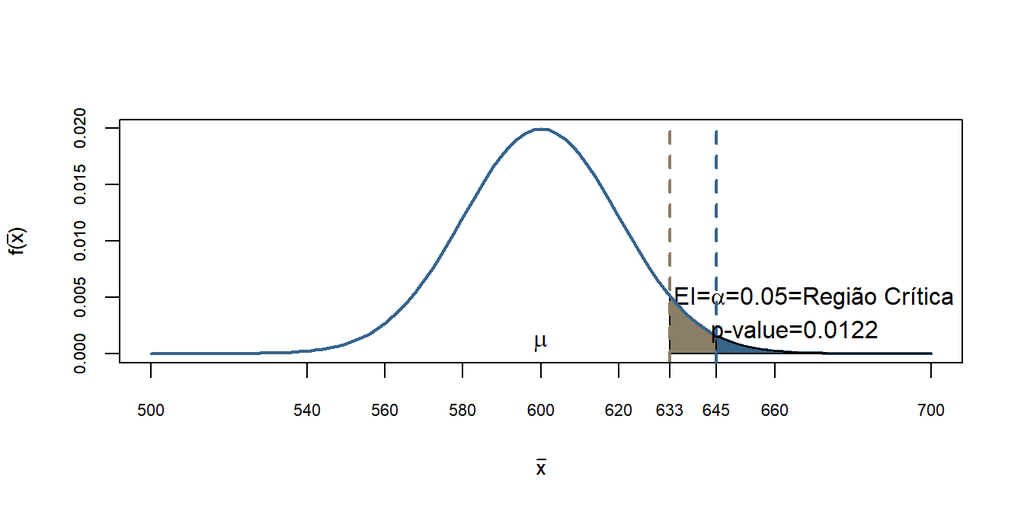

Nível de significância e p-valor

## Relação entre o p-valor e região crítica

- Em marrom, linha mais a esquerda, temos o limite da região crítica, ou seja, o valor a partir do qual rejeitariamos $H_0$.
  - Note que podemos montar essa região sem efetivamente retiramos uma amostra, somente com base na teoria e no tamanho amostral que poderiamos coletar.
  - Especifica todas os valores sob os quais rejeitamos $H_0$.
- O p-valor está indicado pela linha azul no gráfico e nos fornece a ideia de quão forte é essa rejeição
  - Quanto menor o p-valor (valores mais extremos) mais evidências temos de que a hipótese nula $H_0$ não é adequada

## Os Cinco passos para a contrução do teste de hipótese

1. Estabeleça as hipótese nula $H_0$ e a hipótese alternativa $H_1$
2. Defina qual estimador do parâmetro populacional $\theta$ que será usado para testar $H_0$: média, desvio padrão amostral, proporção amostral etc
3. Defina o nível de significância - $\alpha$ e estabeleça qual o valor e a região crítica.
4. Calcule a estimativa do teste estatístico.
5. Se não pertencer a Região Crítica não rejeitamos $H_0$, caso contrário rejeitamos a hipótese nula $H_0$.

# Teste de Hipótese na Prática

## Teste sobre parâmetros locacionais

## Testes para Esperança pop. com variância conhecida

- Conhecemos $\sigma$

**1- Definindo a Hipótese**:
$$H_0: \mu=\mu_0$$
$$H_1: \mu \neq \mu_0$$
ou

$$H_0: \mu=\mu_0$$
$$H_1: \mu >\mu_0 \quad ou \quad H_1: \mu<\mu_0$$

## Testes para Esperança pop. com variância conhecida

**2 - Definindo o Estimador**:

- Média é um bom estimador para a esperança:
  $$\bar{X}\sim N(\mu,\sigma^2/n)$$
- Sob $H_0$ temos o seguinte:
  $$\bar{X}\overset{H_0}{\sim} N(\mu_0,\sigma_0^2/n)$$
- Logo o nosso Teste Estatístico $T$, sob $H_0$ será :

$$T=\frac{\bar{X}-\mu_0}{\sigma_0/\sqrt{n}}\overset{H_0}{\sim} N(0,1)$$

## Testes para Esperança pop. com variância conhecida

**3 - Nivel de Significância e Região Crítica**

- Em economia utilizamos 10%, 5% e 1%. Regiões críticas para o teste:
  $$H_0: \mu=\mu_0$$
  $$H_1: \mu \neq \mu_0$$
  $$RC=\{t \in \mathbb{R} |t\leq - z_{c,\alpha/2} \quad \cup \quad t\geq z_{c,\alpha/2}\}$$

$$H_0: \mu=\mu_0$$
$$H_1: \mu >\mu_0 \quad ou \quad H_1: \mu<\mu_0$$
$$RC_1=\{t \in \mathbb{R} | t\geq z_{c,\alpha}\}$$
ou
$$RC_2=\{t \in \mathbb{R} |t\leq - z_{c,\alpha} \}$$

## Testes para Esperança pop. com variância conhecida

**4 - Cálculo do Teste Estatístico**

- Logo o valor do nosso teste estatístico será:
  $$t=\frac{\bar{x}-\mu_0}{\sigma_0/\sqrt{n}}$$
- Podemos comparar esse valor obtido com os valores ditos mais prováveis de ocorrerem sob $H_0$.
- Basicamente faremos isso comparando o valor obtido, $t$ com a nossa região crítica.

## Testes para Esperança pop. com variância conhecida

**5 - Teste de hipótese**

Assim se a nossa estimativa $t$ pertencer a regiao crítica rejeitamos $H_0$, ou seja, há evidências de que a afirmativa esteja errada. Caso não esteja na RC não rejeitamos $H_0$ e portanto temos evidência de que esteja correto.

## Exemplo

## Testes para Esperança pop. com variância conhecida

**EXEMPLO**

Suponha que temos uma máquina de empacotar que tem uma regulagem original com $\mu=500$ e $\sigma^{2}=400$. O gerente de qualidade da empresa mensalmente faz a aferição para verificar se a máquina está desregulada. Ele coleta aleatóriamente $n=16$ pacotes e obteve a média $\bar{x}=492$. O gerente deve parar a produção e chamar a equipe de manutenção ao nível de 1% de significância?

## Testes para Esperança pop. com variância conhecida

**1 - Definindo a hipótese**:

- Nesse caso utilizamos a hipótese bilateral.

$$H_0: \mu=500 g$$

$$H_{1}: \mu \neq 500 g$$

**2 - Definindo o Estimador**:

- O estimador de $\mu$ é a média $\bar{X}$:
- O Teste Estatístico $T$, sob $H_0$ será :

$$T=\frac{\bar{X}-500}{20/\sqrt{16}}\overset{H_0}{\sim} N(0,1)$$

## Testes para Esperança pop. com variância conhecida

**3 - Nivel de Significância e Região Crítica**:

- Considerando o nível de 1% de significância temos:

$$RC= \{ t \in \mathbb{R}| t\leq -2.58 \quad \cup \quad t\geq 2,58 \}$$

**4 - Cálculo do Teste Estatístico**: - Com base nas 16 elementos amostrados de $X$, obtivemos:
$$\bar{x}=\frac{\sum_i{x_i}}{16}=492$$
Logo o valor do nosso teste estatístico será:

$$t=\frac{492-500}{20/4}=\frac{-8}{5}=-1.6$$

## Testes para Esperança pop. com variância conhecida

**5 - Teste de Hipótese**:

- Com base no $t$ calculado procedemos o teste de hipótese. Sabendo que a RC é:
  $$RC= \{ t \in \mathbb{R}| t\leq -2.58 \quad \cup \quad t\geq 2,58 \}$$

Como $t=-1.6$ ele não pertence a região, logo não rejeitamos $H_0$, não há evidências de que a máquina desregulou e o gerente não deveria parar a produção para fazer a manutenção.

## Testes para Esperança pop. com variância conhecida

- Uma outra maneira é encontrarmos quais são os limites da região crítica na distribuição de $\bar{X}$.
- Assim ao nível de significância, $\alpha$ de 1%:
  $$z_{c_1}=-2,58=(\overline{x}_{c1}-500)/5=487,1$$
  $$Z_{c_2}=2,58=(\overline{x}_{c2}-500)/5=512,9$$
- Logo a região crítica análoga na distribuição de $\bar{X}$ será:

$$RC=\{\overline{x} \in R | \overline{x} \leq 487,1 \ \text{ou} \ \overline{x}\geq512,9 \}$$

Como a amostra tem média $\overline{x}=492$ ela não pertence à região críitica então não rejeitamos $H_0$.

## Testes para Esperança pop. com variância conhecida

[figure not shown]

Nível de significância e p-valor

## Utilizando o p-valor

- Faremos agora um teste de hipótese o p-valor.
- Não construiremos mais a região crítica e iremos calcular com base no valor do teste estatístico:

$$P(T\geq t_0|H_0)=p-valor=\hat{\alpha}$$

## Utilizando o p-valor

**EXEMPLO**

Uma empresa de transporte intermunicipal que ganhou uma concessão do Estado afirma que o tempo de viagem, $X$, entre duas cidades de acordo com seus estudos preliminares pode ser assim descrito:

$$\begin{array}{ccc}
X \sim N (300,30^{2})
\end{array}$$

Inclusive esse tempo foi um dos critérios utilizados no processo de cessão. O Ministério Público desconfia e acredita que esse valor é maior. O MP faz um estudo considerando 10 viagens aleatórias e encontra que $\overline{x}=314$. O MP deve se reunir com a empresa e pedir um ajustamento de conduta?

## Utilizando o p-valor

**1 - Definindo a hipótese**:

$$H_0: \mu=300$$

$$H_1: \mu\geq 300$$

**2 - Definindo o Estimador**: Sabemos que $\bar{X}$ será:

- Considerando que a empresa está correta, ou seja, sob $H_0$:

$$\begin{array}{ccc}
\overline{X} \sim N (300; 900/10)
\end{array}$$

**3 - Nivel de Significância e Região Crítica**: Não precisamos mais calcular!!

## Utilizando o p-valor

**4 - Cálculo do Teste Estatístico**:

- Calculamos a probabilidade de ocorrência de amostras com o valor iguais ou superiores a $\overline{x}=314$ sob $H_0$:
  $$\begin{array}{ccc}
  P(\bar{x}>314)=P(z>\frac{314-300}{9.49})=P(z>1,48)=0,07
  \end{array}$$

$$\begin{array}{ccc}
\hat{\alpha}=p-valor=7\%
\end{array}$$

- Caso fosse bicaudal e sabendo que a distribuição é simétrica poderiamos considerar: $\hat{\alpha}=14\%$

## Utilizando o p-valor

**5 - Teste de Hipótese**: Considerando o teste unilateral, temos agora a força da rejeição. A chance de retirarmos 314 ou mais é de 7%. Apesar de baixo poderia ocorrer. Não parece muito improvável, tanto que se considerarmos $\alpha=1\%$ ou $\alpha=5\%$ não rejeitamos. Só rejeitariamos $H_0$ se $\alpha=10\%$. Podemos concluir que as evidências não nos revelam que a empresa está tendo um tempo maior de viagem, apesar dessa conclusão não ser tão forte.

## Teste sobre a Esperança de uma pop. normal com variância desconhecida

- O procedimento aqui é análogo ao que fizemos anteriormente
- Entretanto o novo teste estatístico será:

$$T=\frac{\bar{X}-\mu_0}{S_X/\sqrt{n}}$$

- Nossa questão agora é qual a distruibuição desse teste?
- Agora tanto $\bar{X}$ como $S_X$ são variáveis aleatórias e possuem distriuição.
- Temos a divisão de uma normal $N(0,1)$ por $\sqrt{\chi^2_{n-1}}$ dividido pelo número de graus de liberdade
- Portanto nosso teste estatístico será:

$$T=\frac{\sqrt{n}(\bar{X}-\mu)}{S_X} \sim t(n-1)$$

- E terá uma distribuição t-student com n-1 graus de liberdade.

## Teste sobre a Esperança de uma pop. normal com variância desconhecida

- Região crítica tem que ser construída com base na tabela da distribuição t.Para o caso bicaudal:

$$RC=\{t \in \mathbb{R} |t\leq - t_{c,\alpha/2} \quad ou \quad t\geq t_{c,\alpha/2}\}$$
Para o caso unicaudal:

$$RC_1=\{t \in \mathbb{R} | t\geq t_{c,\alpha}\} \quad ou \quad RC_2=\{t \in \mathbb{R} |t\leq -t_{c,\alpha} \}$$

## Exemplo

## Teste sobre a Esperança de uma pop. normal com variância desconhecida

**EXEMPLO**

Um fabricante afirma que seus cigarros não contém mais do que 30mg de nicotina. O Ministério da Saúde está desconfiado dessa afirmativa e acredita que o conteúdo de nicotina é maior do que o anunciado (teste unilateral). Foi realizada uma amostra de 25 cigarros e o teor médio de nicotina nos mesmos foi $\overline{x_0}=31,5mg$ e o desvio padrão amostral $S_X=3mg$. Com $\alpha=5\%$ os dados confirmam a informação?

## Teste sobre a Esperança de uma pop. normal com variância desconhecida

**1 - Definindo a hipótese**:
$$H_0: \mu=30$$
$$H_1: \mu\geq30$$

**2 - Definindo o Estimador**: - O Teste Estatístico $T$, que nesse caso é a padronização de $\bar{X}$ e considerando o estimador da variância será, sob $H_0$:

$$T=\frac{\bar{X}-30}{3/\sqrt{25}}\overset{H_0}{\sim} t(24)$$

**3 - Nivel de Significância e Região Crítica**: - Considerando o nível de 5% de significância e teste unilateral temos:

$$RC=\{t \in \mathbb{R} |t\geq t_{24,0.05} \}= \{t \in \mathbb{R} |t\geq 1,711 \}$$

**4 - Cálculo do Teste Estatístico**:

- Foram amostrado 25 elementos de $X$, obtivemos $\bar{x}=31.5$
- Logo o valor do nosso teste estatístico será:
  $$t=\frac{31.5-30}{3/5}=\frac{1.5}{0.6}=2.5$$

**5 - Teste de Hipótese**: Nosso teste foi $T=2.5$ e nossa região crítica $RC=\{t\geq 1,711 \}$. Logo pertence à região crítica. Dessa forma, rejeitamos $H_0$ mostrando que há evidências de que o teor de nicotina é maior do que o anunciado pela firma.

**6 - Extra 1: p-valor**:

- Probabilidade de encontrarmos os valores $T=2.5$ ou maiores em uma amostra que veio de uma população sob $H_0$ ou seja, $\mu=30g$.

$$\hat{\alpha}=P\left(T>t_{0}| H_{0}\right)=P\left(T>2,5 | H_{0}\right)=0,01$$

- O que também leva à rejeição de $H_0$ ao nível de 5% de confiança.

## Teste sobre a Esperança de uma pop. normal com variância desconhecida

**7 - Extra 2: O Intervalo e Confiança**: - Como rejeitamos, poderiamos estar interessados em descobrir onde estaria a verdadeira média populacional ao nível de 5% de confiança. - Vamos calcular o intervalo de confiança para 5% ( $t_\gamma=2,064$):

$$\begin{array}{ccc}
I C(\mu ; 0.95)=31,5 \pm(2.064) 3/\sqrt{25}
\\
\\
I C(\mu ; 0.95)=\{30.26 ; 32.74\}
\\
\\
\end{array}$$

- Logo o verdadeiro parâmetro populacional $\mu$ estaria entre $30.26$ e $32.74$.

**8 - Extra 3: Simulando o nosso problema**:

## Teste sobre a Esperança de uma pop. normal com variância desconhecida

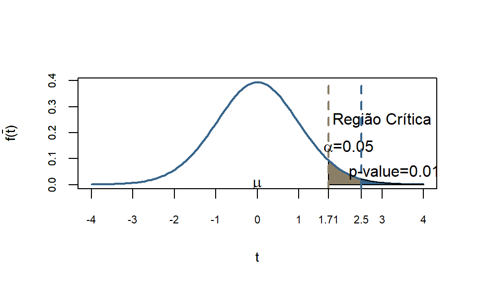

Nível de significância e p-valor para distribuição t-student

## Comparação de duas populações normais: amostra independente

- Saber se uma população possui o mesmo valor de esperança que a outra população. - Por exemplo se a renda per capita é da cidade é igual a renda per capita no campo.
- Agora comparamos duas médias $H_0:\mu_1=\mu_2$. Aqui assumimos que elas são normais e as amostras são independentes:
  $$P_1 \sim N(\mu_1,\sigma^2_1)$$
  $$P_2 \sim N(\mu_2,\sigma^2_2)$$

## Comparação de duas populações normais: amostra independente

**1 - Definindo a hipótese**:
$$H_0: \mu_1=\mu_2$$
$$H_1: \mu_1\neq\mu_2$$

**2 - Definindo o Estimador**:

- Supondo que retiramos uma amostra de $n$ elementos da população 1 $X$ e de $m$ elementos da população 2, $Y$. Sob $H_0$ temos:
  $$\begin{array}{ccc}
  \mathbb{E}(\overline{X}-\overline{Y})=\mathbb{E}(\overline{X})-\mathbb{E}(\overline{Y})=\mu_X-\mu_Y=0
  \\
  Var(\overline{X}-\overline{Y})=Var(\overline{X})+Var(\overline{Y})=\frac{\sigma^2_X}{n}+\frac{\sigma^2_Y}{m}
  \end{array}$$

## Comparação de duas populações normais: amostra independente

**2.1 - Caso 1: Para variâncias conhecidas**

- Sob a hipótese de que $H_0$ é verdadeira:

$$T=\frac{(\overline{X}-\overline{Y})-(\mu_X-\mu_Y)}{\sqrt{\frac{\sigma^2_X}{n}+\frac{\sigma^2_Y}{m}}}\Rightarrow T=\frac{(\overline{X}-\overline{Y})}{\sqrt{\frac{\sigma^2_X}{n}+\frac{\sigma^2_Y}{m}}}\sim N(0,1)$$

- Construímos a região crítica com base na normal padrão
- O intervalo de confiança nesse casos seria:
  $$IC(\theta;\gamma)=(\overline{x_0}-\overline{y_0})\pm z_{\gamma}\sqrt{\frac{\sigma^2_X}{n}+\frac{\sigma^2_Y}{m}}$$

## Comparação de duas populações normais: amostra independente

**2.2 - Caso 2: Para variância desconhecida e iguais**

- No teste de igualdade de variância essa não foi rejeitada.
- Temos que $S_1^2$ e $S_2^2$ são dois estimadores não viesados de $\sigma^2$.
- Retiramos uma amostra de $n$ elementos da população 1 $X$ e de $m$ elementos da população 2, $Y$. Assim:

$$S_p^2=\frac{(n-1)S_X^2+(m-1)S_Y^2}{n+m-2}$$

- Para testar a hipótese nula utiliza-se:

$$T=\frac{\overline{X}-\overline{Y}}{S_p\sqrt{\frac{1}{n}+\frac{1}{m}}}\sim t_{(n+m-2)}$$

## Comparação de duas populações normais: amostra independente

**2.2 - Caso 2: Para variância desconhecida e iguais**

- Construímos nossa região crítica com base na distribuição t-student $t_{\alpha,(n+m-2)}$
- O Intervalo de confiança será:

$$\begin{array}{ccc}
IC(\theta;\gamma)=(\overline{x_0}-\overline{y_0})\pm t_{\gamma,(n+m-2)}S_p\sqrt{\frac{1}{n}+\frac{1}{m}}
\end{array}$$

## Comparação de duas populações normais: amostra independente

**2.3 - Caso 3: Para variância desconhecida e desiguais**

- Hipótese de igualdade de variância for rejeitada:
  $$T=\frac{\overline{X}-\overline{Y}}{\sqrt{S_X^2/n+S_Y^2/m}}\sim t_{(v)}$$
- Para encontrar o grau de liberdade $v$:

$$v=\frac{(A+B)^2}{\frac{A^2}{(n-1)}+\frac{B^2}{(m-1)}}$$
onde:
$$A=\frac{S_X^2}{n} \qquad B=\frac{S_Y^2}{m}$$

## Comparação de duas populações normais: amostra independente

**2.3 - Caso 3: Para variância desconhecida e desiguais**

- Região crítica é elaborada com base na distribuição t-student $t_{\alpha,(v)}$
- O Intervalo de confiança será:

$$\begin{array}{ccc}
IC(\theta;\gamma)=(\overline{x_0}-\overline{y_0})\pm t_{\gamma,(v)}\sqrt{S_1^2/n+S_2^2/m}
\end{array}$$

## Exemplos

## Comparação de duas populações normais: amostra independente

**EXEMPLO**

**Teste de diferença de médias com variância conhecidas**:

Uma empresa propos um novo sistema de monitoramento de processo e quer verificar se esse faz com que os funcionarios tenham melhor performance. Foi feito um ensaio com 8 funcionários sob o monitoramento atual $(X)$ e a performance média registrada foi de 80.5 pontos. Sabe-se que o desvio padrão populacional, $\sigma_X=1.5$. Foi feito outro ensaio com 10 funcionários sob o novo monitoramento $(Y)$ e a performance foi de 81.3 pontos. Aqui também conhecemos o desvio padrão populacional, $\sigma_X=3.8$

## Comparação de duas populações normais: amostra independente

**1 - Definindo a hipótese**:

- Teste unilateral:
  $$H_0: \mu_X=\mu_Y$$
  $$H_1: \mu_X\leq\mu_Y$$

**2 - Defindo o Estimador**:  
- Para variância conhecida e sob a hipótese nula temos:

$$T=\frac{(\overline{X}-\overline{Y})}{\sqrt{\frac{\sigma^2_X}{n}+\frac{\sigma^2_Y}{m}}}\sim N(0,1)$$

**3 - Nivel de Significância e Região Crítica**: - Considerando o nível de 5% de significância e teste unilateral temos:

$$RC=\{t \in \mathbb{R} |t\leq z_{c,0.05} \} = \{t \in \mathbb{R} |t\leq -1.645 \}$$

## Comparação de duas populações normais: amostra independente

**4 - Cálculo do Teste Estatístico**:

- Calculando:

$$T=\frac{(\overline{X}-\overline{Y})}{\sqrt{\frac{\sigma^2_X}{n}+\frac{\sigma^2_Y}{m}}}= \frac{(80.5-81.3)}{\sqrt{\frac{1.5^2}{8}+\frac{3.8^2}{10}}}= -0.61\sim N(0,1)$$

**5 - Teste de Hipótese**:

Como -0.61 não está na região crítica, não rejeitamos a hipótese nula de que os dois processos de monitoramento produzem o mesmo resultado. Isso indica que se houver algum custo adicional na implementação do monitoramento 2, esse será um prejuízo para a empresa.

**6 - Simulando as duas distribuições**:

## Comparação de duas populações normais: amostra independente

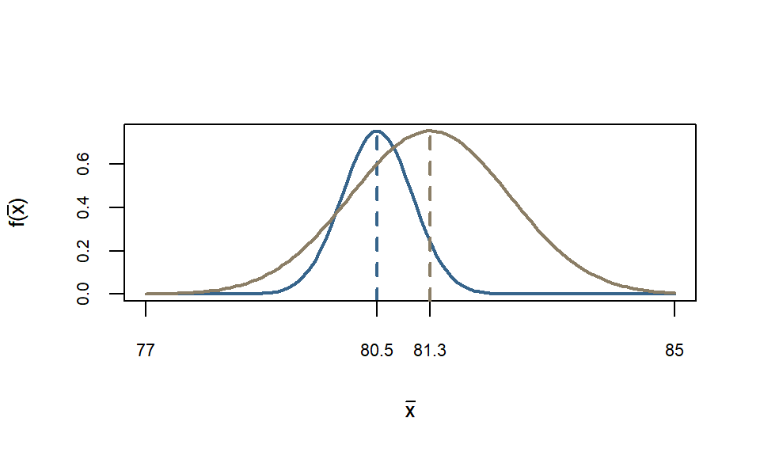

Simulando as duas distribuições do monitoramento, supondo normal

## Exemplo

## Comparação de duas populações normais: amostra independente

**EXEMPLO**

**Teste de diferença de médias com variância desconhecidas e iguais**:

Uma empresa está testando duas misturas de concretos os quais são feitos com cimento de diferentes minas. A mistura 1 é a mistura padrão feita com o cimento já conhecido. A mistura 2 usa a mesma receita mas utiliza um cimento vindo de uma nova mina. A empresa quer saber se as duas misturas produzem a mesma qualidade de produto, ou seja, que a carga de ruptura do concreto após 28 dias é a mesma em $kg/cm^2$. A tabela abaixo traz os testes laboratoriais e gostariamos de saber se ao nível de 5% de confiança as duas misturas possuem a mesma esperança?

## Comparação de duas populações normais: amostra independente

- Os dados:

Table 2: Resistência de diversas amostras de concreto (Carga de Ruptura $kg/cm^2$)

| Mistura | Amostras |
| --- | --- |
| **Mistura 1** | 15,4; 15,7; 14,8; 15,7; 14,8; 15,6; 15,4; 14,6; 15,8; 15,3; 15,5; 15,2 |
| **Mistura 2** | 14,7; 14,3; 14,5; 14,2; 15,0; 14,8; 15,2; 15,3; 14,9; 15,4 |

## Comparação de duas populações normais: amostra independente

- Considerando que $X$ é a carga de ruptura da mistura 1 $Y$ é a carga de ruptura da mistura 2. Temos:

$$\begin{array}{ccc}
n=12 \ \qquad \sum_iX_i=183.8 \ \qquad \sum_iX_i^2=2816.92
\\
\\
m=10 \ \qquad \sum_iY_i=148.3 \ \qquad \sum_iY_i^2=2200.81
\\
\\
\overline{X}=\frac{\sum_iX_i}{n}=15.316 \qquad \overline{Y}=\frac{\sum_iY_i}{n}=14.83
\end{array}$$

$$\begin{array}{ccc}
S_X^2=\frac{\sum_iX_i^2-2\overline{X}\sum_iX_i+n\overline{X}^2}{n-1}=0.1561 \Rightarrow S_X=0.395
\\
\\
S_Y^2=0,1690 \Rightarrow S_Y=0.411
\end{array}$$

## Comparação de duas populações normais: amostra independente

**1 - Definindo a hipótese**:
$$H_0: \mu_X=\mu_Y$$
$$H_1: \mu_X\neq\mu_Y$$

**2 - Defindo o Estimador**:

- Para variância desconhecida e iguais e ambas as populações normal.
- Sob a hipótese nula tem-se:

$$T=\frac{\overline{X}-\overline{Y}}{S_p\sqrt{\frac{1}{n}+\frac{1}{m}}}\sim t_{(n+m-2)}$$
Sendo:
$$S_p^2=\frac{(n-1)S_X^2+(m-1)S_Y^2}{n+m-2}$$

## Comparação de duas populações normais: amostra independente

**3 - Nivel de Significância e Região Crítica**:

- Considerando o nível de 5% de significância e teste bilateral temos

$t_{(12+10-2)}=t_{(20;0.025)}$:

$$RC= \{t \in \mathbb{R} |t\leq -2.086 \quad \cup \quad t\geq 2.086 \}$$

**4 - Cálculo do Teste Estatístico**:

Calculando a variância ponderada:

$$S_p^2=\frac{(n-1)S_X^2+(m-1)S_Y^2}{n+m-2}=\frac{(11)0.1561+(9)0.169}{12+10-2}= 0.1619$$

## Comparação de duas populações normais: amostra independente

**5 - Teste de Hipótese**:

Como 2.84 está na região crítica rejeitamos a hipótese de que as duas misturas produzem concretos com a mesma carga de ruptura, indicando que há evidências de que a carga de ruptura da nova mistura 2 é menor do que a mistura original.

**6 - Extra: Simulando as duas distribuições**:

- Podemos observar as duas distribuições da média para a mistura 1 e para a mistura 2.
- Observa-se que elas estão distantes uma da outra indicando visualmente que elas vem de populações distintas.

## Comparação de duas populações normais: amostra independente

[figure not shown]

## Testes Paramétricos sobre Probabilidades

## Teste para proporção

- Respostas binárias
- Pesquisas eleitorais, pessoas favoráveis a uma política, empresas que entraram em recuperação judicial, indivíduos que possuem dívida em atraso etc. Vamos trabalhar aqui com a estratégia de aproximação da binomial pela normal.

**1- Definindo a Hipótese**: - Podemos definir de forma Bicaudal ou Unicaudal
$$H_0: p=p_0$$
$$H_1: p \neq p_0$$
ou

$$H_0: p=p_0$$
$$H_1: p >p_0 \quad ou \quad H_1: p<p_0$$

## Teste para proporção

**2 - Definindo o Estimador**:

- O estimador para a proporção seria $\hat{p}=\frac{\sum_i{X_i}}{n}$.
- $X$ tem distribuição binomial. $\mu=np$ e que $\sigma^2=np(1-p)$.
- Para um $n$ suficientemente grande,$X \sim b(n,p)$ pode ser aproximado por $N(np,np(1-p))$.
- Como, $\hat{p}=\frac{\sum_i{X_i}}{n}$, a distribuição da proporção amostral será $\hat{p} \sim N(p,p(1-p)/n)$
- Portanto Sob $H_0$ o nosso Teste Estatístico $T$, será :

$$T=\frac{\hat{p}-p_0}{\sqrt{p_0(1-p_0)}}\sqrt{n}\overset{H_0}{\sim} N(0,1)$$

## Teste para proporção

**3 - Nivel de Significância e Região Crítica**

- Novamente em economia utilizamos 10%, 5% e 1%:
  $$H_0: p=p_0$$
  $$H_1: p \neq p_0$$
  $$RC=\{t \in \mathbb{R} |t\leq - z_{c,\alpha/2} \quad \cup \quad t\geq z_{c,\alpha/2}\}$$

$$H_0: p=p_0$$
$$H_1: p >p_0 \quad ou \quad H_1: p<p_0$$
$$RC_1=\{t \in \mathbb{R} | t\geq z_{c,\alpha}\}$$
ou
$$RC_2=\{t \in \mathbb{R} |t\leq - z_{c,\alpha} \}$$

## Teste para proporção

**4 - Cálculo do Teste Estatístico**

- Nosso teste estatístico será:

$$t=\frac{\hat{p}-p_0}{\sqrt{p_0(1-p_0)}/\sqrt{n}}$$

**5 - Teste de hipótese**

- Assim se a nossa estimativa $t$ pertencer a região crítica rejeitamos $H_0$. Caso não esteja na RC não rejeitamos $H_0$.

## Exemplo

## Teste para proporção

**EXEMPLO**

Temos uma estação de TV que afirma que $60\%$ das Tv’s estavam sintonizadas no seu programa as 20h. Uma emissora concorrente contesta essa afirmação dizendo que na verdade esse percentual é bem menor. Ela contrata uma empresa para verificar quem está com a razão, pois isso tem impactos diretos sobre a quantidade de propaganda que conseguem negociar. Essa empresa contratou você para realizar o teste. Já antecipando fez um processo de amostragem com 200 famílias e ao nível de significância de 5% quem teria razão? (teste unilateral)

## Teste para proporção

**1- Definindo a Hipótese**: - Definindo de forma Unicaudal
$$H_0: p=0,60$$
$$H_1: p<0,60$$

**2 - Definindo o Estimador**:

- Sob $H_0$ temos o seguinte Teste Estatístico.

$$T=\frac{\hat{p}-p_0}{\sqrt{p_0(1-p_0)}/\sqrt{n}}=\frac{\hat{p}-0.6}{\sqrt{0.6(0.4)}}\sqrt{200} \sim N(0;1)$$

## Teste para proporção

**3 - Nivel de Significância e Região Crítica**: - Supondo $H_0$ verdadeira, $\alpha=0,05$ e utilizando a tabela da Normal Padrão:

$$RC=\{t \in \mathbb{R} | t \leq -1.645 \}$$

**4 - Cálculo do Teste Estatístico**: - A mostra de 200 elementos mostrou que 104 lares estavam ligado no programa, ou seja, 52%. - Dessa forma podemos calcular nosso Teste Estatístico:

$$t=\frac{0.52-0.6}{\sqrt{0.6(0.4)}}\sqrt{200} = -2.309$$

- O qual pertence a região crítica.

## Teste para proporção

**5 - Teste de hipótese**:

Assim, como -2.309 está na região crítica rejeitamos, $H_0$. Há evidências de que a emissora não teve $60\%$ da audiência, e sim menos.